# Identification of Gene Signatures of Breast Cancer Subtypes Resistant to CDK4/6 Inhibitors

Daehwan Kim and Prasanna Alluri

28 February, 2018

# Outline

Steps involved in discovery of new drugs that reverse CDK4/6 inhibitor resistance:

1. Develop CDK4/6 inhibitor resistance signature.
2. Screen published databases to identify drugs that reverse the signature identified in step 1 (identical to Chen et al. 2017).
3. Validate findings from step 2 in the lab.

# Initialization

Initialize R session by deleting existing R objects.

```r
rm(list = ls())
```

Load R libraries needed to analyze microarray data and visualize results.

```r
library(affy)
library(affyPLM)
library(GEOquery)
library(genefilter)
library(cluster)
library(randomForest)
library(plyr)
# library(WGCNA)
```

Define utility functions.

```r
printf <- function(...) print(sprintf(...))
```

Settings:

```r
fast_run <- FALSE
```

Load gene expression data (microarray) under GSE12790, which is already included in our GitHub repository (https://github.com/infphilo/cowork_pa).

```r
geo_fname <- "GSE12790_series_matrix.txt.gz"
remote_fname <- paste("ftp://ftp.ncbi.nlm.nih.gov/geo/series/GSE12nnn/GSE12790/matrix/", geo_fname, sep="")
if(!file.exists(geo_fname)) download.file(remotefile, geo_fname)
hoeflich_2009 <- getGEO(filename=geo_fname)
```

Change the names of cell subtypes so that they match those of Finn et al. ({2009})

```r
pd <- pData(hoeflich_2009) # phenotype data
pd$cellLine <- gsub("MCF10a_Null_Vector_rep1", "MCF-10A", pd$title)
pd$cellLine <- gsub(".*_", "", pd$cellLine)
name_change <- c("MDA-MB-175VII", "MDA-MB-175",
                 "ZR75-30", "ZR-75-30",
                 "MDA-MB-134VI", "MDA-MB-134",
                 "HCC202", "HCC-202",
                 "EFM19", "EFM-19",
                 "HCC1500", "HCC-1500",
                 "HCC1419", "HCC-1419",
                 "HCC38", "HCC-38",
                 "HCC2218", "HCC-2218",
                 "ZR75-1", "ZR-75-1",
                 "T47D", "T47-D",
                 "MCF7", "MCF-7",
                 "BT20", "BT-20",
                 "MDA-MB-435s", "MDA-MB-435",
                 "BT474", "BT-474",
                 "SKBR3", "SK-BR-3",
                 "KPL1", "KPL-1",
                 "HCC1143", "HCC-1143",
                 "HCC1395", "HCC-1395",
                 "Hs578T", "Hs578t",
                 "HCC1569", "HCC-1569",
                 "HCC1937", "HCC-1937",
                 "HCC1954", "HCC-1954",
                 "HCC70", "HCC-70")
for(i in 1:(length(name_change)/2)) {
  pd$cellLine <- gsub(name_change[i*2-1], name_change[i*2], pd$cellLine)
}
hoeflich_2009$cellLine <- pd$cellLine
```

Load the list of samples analyzed in Finn et al. ({2009}).

```r
finn_2009 <- read.table("Finn_2009.txt", header = TRUE, sep = "\t")
```

The list includes 47 subtypes. Unfortunately, their gene expression data is not publically available.

Identify and use the cell lines available from Hoeflich et al. ({2009}) that match Finn et al. ({2009}).

```r
selected_cols <- which(pd$cellLine %in% finn_2009$cellLine)
hoeflich_2009 <- hoeflich_2009[,selected_cols]
```

There are 38 subtypes common to both Hoeflich et al. ({2009}) and Finn et al. ({2009}), which we will use in our analysis to identify gene signatures resistant to CDK4/6 inhibitor (e.g. PD 0332991).

The following box plot shows the distribution of gene expression values across those 38 subtypes.

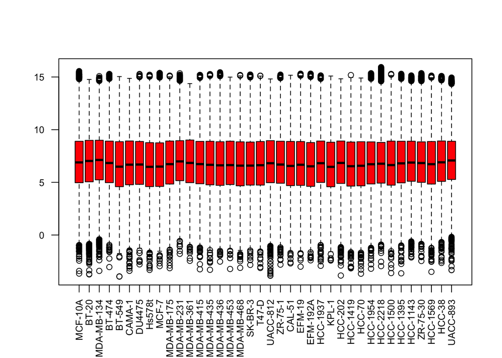

```r
boxplot(log2(exprs(hoeflich_2009)), col="red", las=2, names=hoeflich_2009$cellLine, cex.axis=0.8)
```

The following MVA plot shows M (log ratio) on Y axis and A (mean average) on X axis for a pair of gene expression values (a, b) for each pair of four samples. A is defined as (log(a) + log(b)) / 2 and M is defined as log(a) - log(b).

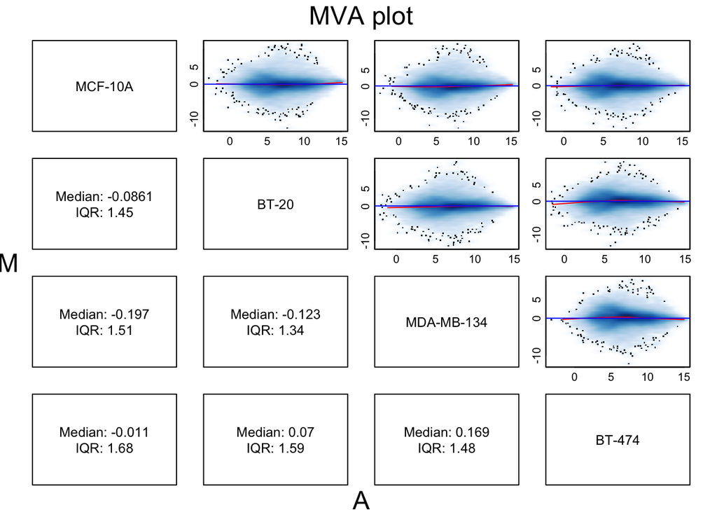

```r
tmp_exprs <- exprs(hoeflich_2009)
colnames(tmp_exprs) <- hoeflich_2009$cellLine
mva.pairs(tmp_exprs[, 1:4], plot.method="smoothScatter", cex=1.2)
```

```r
# Show images of gene expression values - it doesn't work now.
if(FALSE) {
ncol <- (ncol(hoeflich_2009) + 3) / 4
par(mfrow=c(4,ncol))
for(i in 1:ncol(hoeflich_2009)) {
  image(log2(exprs(hoeflich_2009[,i])))
}
}
```

Combine loci into groups that correspond to genes.

```r
h2009_exprs <- as.data.frame(exprs(hoeflich_2009))
locus2gene <- fData(hoeflich_2009)[c("ID", "Gene Symbol")]
stopifnot(rownames(h2009_exprs) == locus2gene$ID)
geneSymbol <- locus2gene$`Gene Symbol`
geneSymbol <- gsub(" ///.*", "", geneSymbol)
h2009_exprs <- cbind(geneSymbol, h2009_exprs)
```

Before gene expression values are combined, the following table shows gene expression values of four samples at WFDC2 and MAPK1, for example.

```r
with(h2009_exprs, {
  h2009_exprs[geneSymbol == 'WFDC2' | geneSymbol == 'MAPK1', 1:5]
})
```

```
##              geneSymbol GSM320243  GSM320590  GSM320592   GSM320596
## 1552261_at        WFDC2    58.546   51.44777   23.63561    7.829851
## 1552263_at        MAPK1   481.278  449.47660  249.45170   85.032500
## 1552264_a_at      MAPK1   660.067  683.46380  702.34700 1222.423000
## 1553089_a_at      WFDC2    11.965   13.98372   23.71795   24.467510
## 203892_at         WFDC2   631.863  227.85380  269.07880  196.356000
## 208351_s_at       MAPK1   913.922  467.39560  727.88290 1182.547000
## 212271_at         MAPK1  2472.879 2471.94800 2560.11500 3434.747000
## 224620_at         MAPK1    14.418   36.73162   19.08121   17.831600
## 224621_at         MAPK1  3525.453 3134.78300 3818.44400 3218.701000
## 229847_at         MAPK1    95.637  117.45940   88.00325   88.969590
```

Merge gene expression values that belong to the same gene by the mean of the values.

```r
h2009_exprs <- aggregate(h2009_exprs[,2:ncol(h2009_exprs)], by = list(geneSymbol), FUN = mean)
rownames(h2009_exprs) <- h2009_exprs[,1]
h2009_exprs <- h2009_exprs[,-1]
```

```r
h2009_exprs[c("WFDC2", "MAPK1"), 1:4]
```

```
##       GSM320243  GSM320590 GSM320592  GSM320596
## WFDC2  234.1247   97.76176  105.4775   76.21779
## MAPK1 1166.2363 1051.60829 1166.4750 1321.46453
```

Transform the gene expression values (0.094 to 60845) to a log scale (-3.4111954 to 15.8928608).

```r
h2009_exprs <- log2(h2009_exprs)
```

For example, the log transformed gene expression values at MAPK1 are as follows:

```
##       GSM320243 GSM320590 GSM320592 GSM320596
## MAPK1  10.18764  10.03838  10.18794  10.36792
```

Add GEO ID to Finn et al. ({2009}) data.

```r
h2009_pd <- pData(hoeflich_2009)
finn_2009 <- merge(finn_2009, h2009_pd[, c("geo_accession", "cellLine")])
```

The list of samples analyzed in Finn et al. ({2009}) are:

```
##      cellLine IC50 breastCancerSubtype ERStatus   HER2Status geo_accession
## 25 MDA-MB-175    4             Luminal Positive       Normal     GSM320603
## 38   ZR-75-30    5             Luminal Positive    Amplified     GSM320633
## 5      CAMA-1    8             Luminal Positive       Normal     GSM320599
## 24 MDA-MB-134   13             Luminal Positive       Normal     GSM320592
## 16    HCC-202   21             Luminal Positive    Amplified     GSM320623
## 36   UACC-893   24             Luminal Positive    Amplified     GSM320638
## 7      EFM-19   27             Luminal Positive       Normal     GSM320618
## 8    EFM-192A   42             Luminal Positive    Amplified     GSM320619
## 27 MDA-MB-361   44             Luminal Positive    Amplified     GSM320605
## 12   HCC-1500   45             Luminal Positive       Normal     GSM320629
## 11   HCC-1419   51             Luminal Positive    Amplified     GSM320624
## 18     HCC-38   64               Basal Negative       Normal     GSM320636
## 28 MDA-MB-415   64             Luminal Positive       Normal     GSM320606
## 22    MCF-10A   92                 n/a Negative Immortalized     GSM320243
```

[output cut: 24 more lines]

Identify genes that are differentially expressed either positively or negatively across 38 breast cancer subtypes according to IC50 values.

```r
gene_names <- rownames(h2009_exprs)

stopifnot(finn_2009$geo_accession == colnames(h2009_exprs))
IC50 <- finn_2009$IC50
logIC50 <- log(IC50)
cor_table <- data.frame(matrix(nrow=length(gene_names), ncol=2))
colnames(cor_table) <- c("locus", "cor")

cor_table[,1] <- gene_names
cor_table[,2] <- apply(h2009_exprs, 1, function(x) cor(x, logIC50, method="pearson"))
cor_order <- order(cor_table$cor)
```

The following is a histogram of correlation values between IC50 and gene expression.

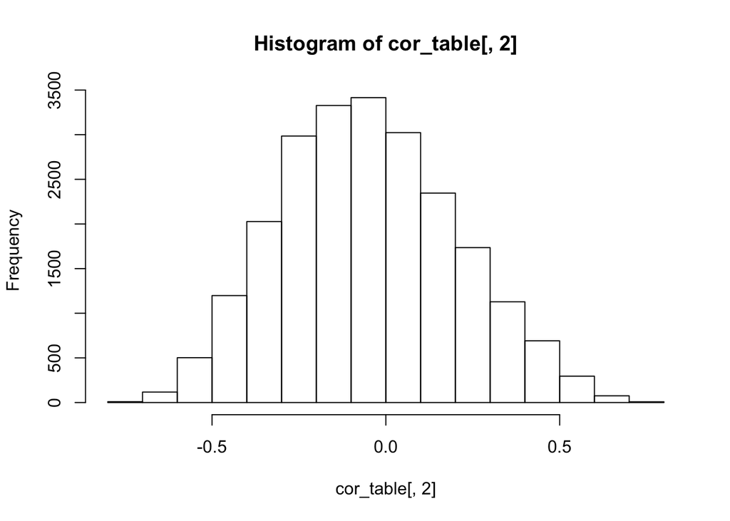

```r
hist(cor_table[,2])
```

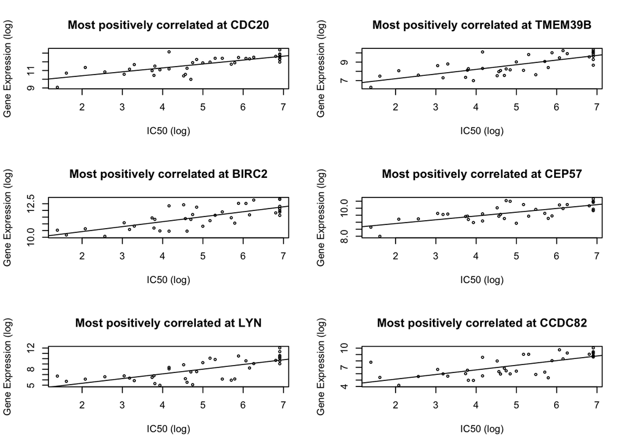

```r
gene_names <- rownames(h2009_exprs)
par(mfrow = c(3,2))
for(i in cor_order[length(cor_order):(length(cor_order)-5)]) {
  plot(x=logIC50, y=h2009_exprs[i,], cex=0.5, xlab="IC50 (log)", ylab="Gene Expression (log)", main=paste("Most positively correlated at", gene_names[i]))
  abline(lm(t(h2009_exprs[i,]) ~ logIC50))
}
```

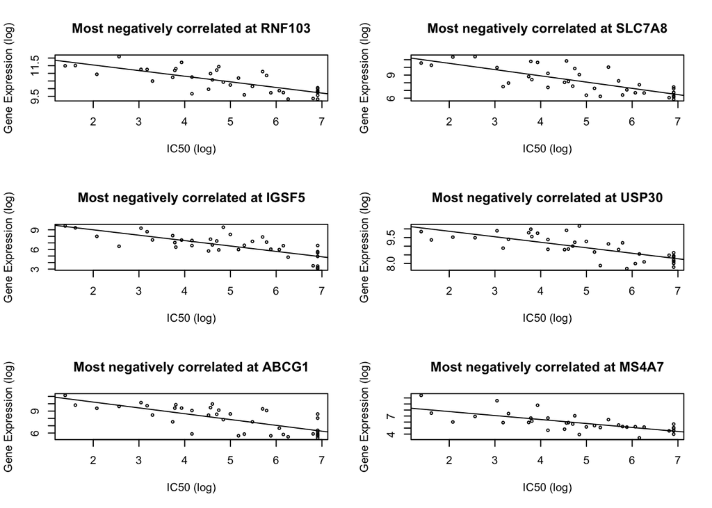

```r
par(mfrow = c(3,2))
for(i in cor_order[1:6]) {
  plot(x=logIC50, y=h2009_exprs[i,], cex=0.5, xlab="IC50 (log)", ylab="Gene Expression (log)", main=paste("Most negatively correlated at", gene_names[i]))
  abline(lm(t(h2009_exprs[i,]) ~ logIC50))
}
```

The following shows a heatmap based on the top 0.1% most positively and negatively correlated genes.

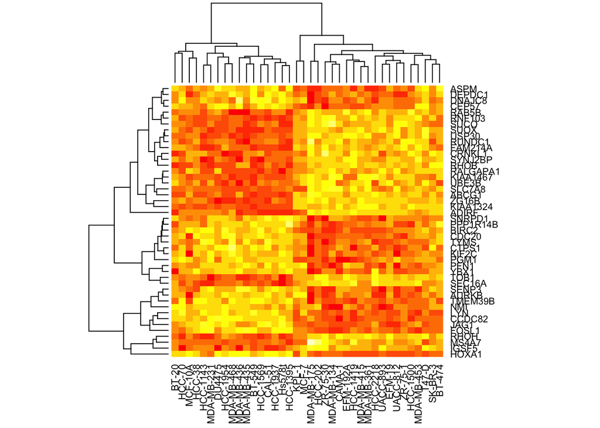

```r
pos_th <- quantile(cor_table$cor, 0.999)
neg_th <- quantile(cor_table$cor, 0.001)

pos_rows <- which(cor_table$cor >= pos_th)
neg_rows <- which(cor_table$cor <= neg_th)
diff_rows <- c(pos_rows, neg_rows)

# Differentially expressed genes
diff_exprs <- as.matrix(h2009_exprs[diff_rows,])
colnames(diff_exprs) <- finn_2009$cellLine
heatmap(diff_exprs)
```

```r
finn_2009[order(finn_2009$IC50), "cellLine"]
```

```
##  [1] MDA-MB-175 ZR-75-30   CAMA-1     MDA-MB-134 HCC-202    UACC-893
##  [7] EFM-19     EFM-192A   MDA-MB-361 HCC-1500   HCC-1419   MDA-MB-415
## [13] HCC-38     MCF-10A    UACC-812   HCC-2218   ZR-75-1    MDA-MB-453
## [19] T47-D      MCF-7      BT-20      MDA-MB-435 BT-474     SK-BR-3
## [25] KPL-1      HCC-1143   MDA-MB-231 HCC-1395   Hs578t     CAL-51
## [31] BT-549     DU4475     MDA-MB-436 MDA-MB-468 HCC-1937   HCC-70
## [37] HCC-1954   HCC-1569
## 47 Levels: 184A1 184B5 BT-20 BT-474 BT-549 CAL-51 CAMA-1 ... ZR-75-30
```

Create Resistance Signature (R-Sig) to mimic Metastasis Signature (M-Sig) developed in Zhao et al. ({2015}) using a random forest of 1,000 trees.

```r
samples <- t(diff_exprs)
stopifnot(rownames(samples) == finn_2009$cellLine)
samples <- cbind(samples, finn_2009$IC50)
colnames(samples)[ncol(samples)] <- "IC50"
train <- sample(1:nrow(samples), nrow(samples) - 5)
rsig <- randomForest(IC50 ~ ., data = samples, subset = train, ntree = 1000)
print(rsig)
```

```
##
## Call:
##  randomForest(formula = IC50 ~ ., data = samples, ntree = 1000,      subset = train)
##                Type of random forest: regression
##                      Number of trees: 1000
## No. of variables tried at each split: 15
##
##           Mean of squared residuals: 58253.23
##                     % Var explained: 53.08
```

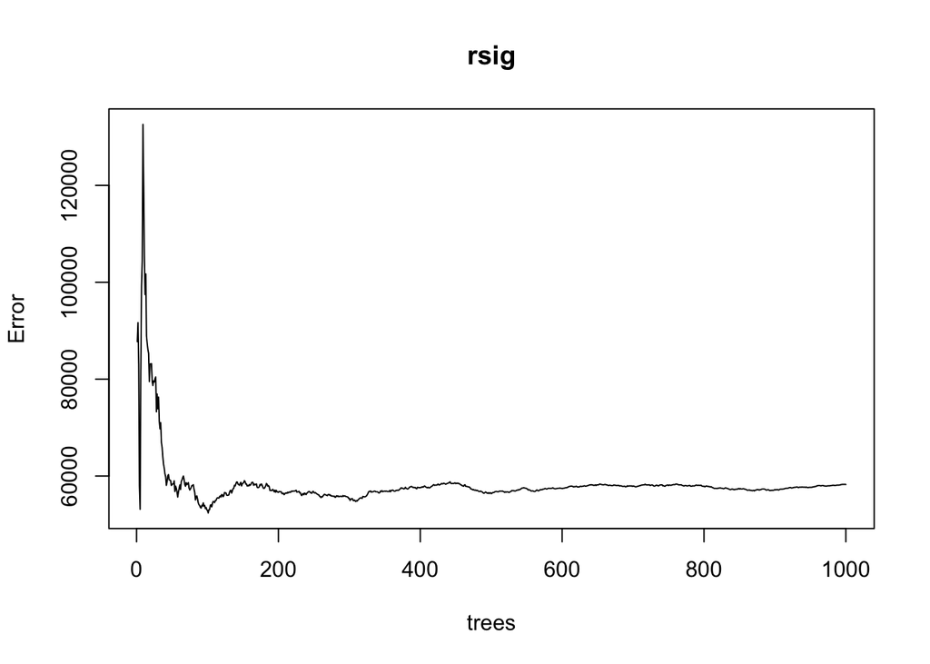

```r
plot(rsig)
```

```r
# print(importance(rsig, type = 2))
```

True IC50 values:

```r
samples[-train, "IC50"]
```

```
## MDA-MB-436    ZR-75-1      KPL-1     HCC-70   HCC-1954
##       1000        110        327       1000       1000
```

Predicted IC50 values:

```r
predict(rsig, samples[-train,])
```

```
## MDA-MB-436    ZR-75-1      KPL-1     HCC-70   HCC-1954
##   684.1696    56.2603   174.4406   588.3930   611.2518
```

Load Library of Integrated Network-based Cellular Signatures (LINCS) database downloaded from http://lincs.hms.harvard.edu/. R data files such as *lincs_signatures_cmpd_landmark.RData* and *lincs_sig_info.csv* are downloaded from B. Chen et al. ({2017}). The following code is taken from B. Chen et al. ({2017}) (https://github.com/Bin-Chen-Lab/RGES) and modified.

```r
load("lincs_signatures_cmpd_landmark.RData")
lincs_sig_info <- read.csv("lincs_sig_info.csv")
lincs_sig_info <- subset(lincs_sig_info, id %in% colnames(lincs_signatures))
lincs_sig_info <- lincs_sig_info[!duplicated(lincs_sig_info$id),]

lincs_gene_info <- read.csv("lincs_landmark.csv")
stopifnot(rownames(lincs_signatures) == lincs_gene_info$gene_id)
rownames(lincs_signatures) <- lincs_gene_info$gene_symbol
```

LINCS contains expression changes of 978 genes across 66511 perturbations in which there are 12442 unique compounds, so the dimension of matrix is 978 x 66511. For example, the following table shows expression changes of 10 genes across 5 perturbations.

```r
lincs_signatures[1:10,1:5]
```

```
##           155341  155393  155435  155493  155500
## PSME1     0.3447 -0.0990  0.6015 -0.8181  1.2216
## ATF1      0.4032 -0.5594  0.0691 -0.2245 -1.0532
## RHEB      1.0289 -1.0509  0.5279 -1.5210 -0.9870
## FOXO3     0.3677 -2.3432  0.0676  1.2043 -0.7199
## RHOA      2.0567 -0.5860  0.5985  0.3303 -0.5947
## IL1B      0.2165  0.4304 -1.2464  0.2711 -0.8849
## ASAH1    -0.6377  0.3013  0.9638  0.4642  1.1086
## RALA     -0.7659 -0.0543  0.1804 -1.5259 -0.7759
## ARHGEF12  2.3798  1.7001  0.8273  0.7445  0.7910
## SOX2      0.3693  1.1346 -0.1842  1.5617 -2.1617
```

The following table shows related information:

```r
lincs_sig_info[lincs_sig_info$id %in% colnames(lincs_signatures)[1:5],]
```

```
##           id                                      sig_id       pert_id
## 49324 155341    DOS058_A375_24H:BRD-K76612659-019-01-0:5 BRD-K76612659
## 49325 155393 DOS053_A375_24H:BRD-K79153888-001-01-3:5.02 BRD-K79153888
## 49326 155435    DOS058_A375_24H:BRD-K81210389-001-01-1:5 BRD-K81210389
## 49327 155493    DOS058_A375_24H:BRD-K84687999-001-01-9:5 BRD-K84687999
## 49328 155500    DOS053_A375_24H:BRD-K85205404-001-01-8:5 BRD-K85205404
##          pert_iname pert_desc cell_id pert_time pert_dose pert_type
## 49324 BRD-K76612659      -666    A375        24      5.00    trt_cp
## 49325 BRD-K79153888      -666    A375        24      5.02    trt_cp
## 49326 BRD-K81210389      -666    A375        24      5.00    trt_cp
## 49327 BRD-K84687999      -666    A375        24      5.00    trt_cp
## 49328 BRD-K85205404      -666    A375        24      5.00    trt_cp
##       is_gold DrugBank.ID
## 49324       1        NULL
## 49325       1        NULL
## 49326       1        NULL
## 49327       1        NULL
## 49328       1        NULL
```

```r
pos_th <- quantile(cor_table$cor, 0.99)
neg_th <- quantile(cor_table$cor, 0.01)
pos_rows <- which(cor_table$cor >= pos_th)
neg_rows <- which(cor_table$cor <= neg_th)

lincs_signatures_pos <- lincs_signatures[rownames(lincs_signatures) %in% gene_names[pos_rows],]
lincs_signatures_neg <- lincs_signatures[rownames(lincs_signatures) %in% gene_names[neg_rows],]
```

The number of genes that match positively and negatively correlated genes to IC50 values are 34 and 16, respectively.

Calculate Reverse Gene Expression Score (RGES) developed by Chen et al. 2017.

```r
gene_list <- rownames(lincs_signatures)

cmap_score <- function(sig_up, sig_down, drug_signature) {
  num_genes <- nrow(drug_signature)

  if(length(sig_up) > 0) {
    up_tags_rank <- merge(drug_signature, sig_up, by.x = "id", by.y = 1)
    up_tags_position <- sort(up_tags_rank$rank)
  } else {
    up_tags_position <- NULL
  }

  if(length(sig_down) > 0) {
    down_tags_rank <- merge(drug_signature, sig_down, by.x = "id", by.y = 1)
    down_tags_position <- sort(down_tags_rank$rank)
  } else {
    down_tags_position <- NULL
  }

  num_tags_up <- length(up_tags_position)
  num_tags_down <- length(down_tags_position)

  ks_up <- 0
  if(num_tags_up > 1) {
    a_up <- max(sapply(1:num_tags_up, function(j) j / num_tags_up - up_tags_position[j] / num_genes))
    b_up <- max(sapply(1:num_tags_up, function(j) up_tags_position[j] / num_genes - (j-1) / num_tags_up))
    if(a_up > b_up) {
      ks_up <- a_up
    } else {
      ks_up <- -b_up
    }
  }

  ks_down <- 0
  if(num_tags_down > 1) {
    a_down <- max(sapply(1:num_tags_down, function(j) j / num_tags_down - down_tags_position [j] / num_genes))
    b_down <- max(sapply(1:num_tags_down, function(j) down_tags_position[j] / num_genes - (j-1) / num_tags_down))
    if(a_down > b_down) {
      ks_down <- a_down
    } else {
      ks_down <- -b_down
    }
  }

  connectivity_score <- ks_up - ks_down
  return(connectivity_score)
}
```

```r
# Test cmap_score function
exp_signature <- data.frame(gene_list,  rank(-1 * lincs_signatures[,1], ties.method="random"))
colnames(exp_signature) <- c("id", "rank")
sorted_exp_signature <- exp_signature[order(exp_signature$rank),]

pos_signature <- sorted_exp_signature[1:50, "id"]
neg_signature <- sorted_exp_signature[(nrow(exp_signature)-49):nrow(exp_signature), "id"]

printf("Testing positive cmap score:")
print(cmap_score(pos_signature, c(), exp_signature))

printf("Testing negitive cmap score:")
print(cmap_score(c(), pos_signature, exp_signature))

printf("Testing positive cmap score2:")
print(cmap_score(c(), neg_signature, exp_signature))

printf("Testing negitive cmap score2:")
print(cmap_score(neg_signature, c(), exp_signature))

printf("Testing positive and negitive cmap score:")
print(cmap_score(pos_signature, neg_signature, exp_signature))

printf("Testing negitive and positive cmap score:")
print(cmap_score(neg_signature, pos_signature, exp_signature))
```

```r
if(fast_run) {
  exp_ids <- lincs_sig_info$id[1:1000]
} else {
  exp_ids <- lincs_sig_info$id
}

dz_genes_up <- gene_names[pos_rows]
dz_genes_down <- gene_names[neg_rows]

cmap_scores <- data.frame(matrix(nrow=length(exp_ids), ncol=2))
colnames(cmap_scores) <- c("exp_id", "score")
cmap_scores$exp_id <- exp_ids
for (i in 1:nrow(cmap_scores)) {
  exp_id <- cmap_scores[i,"exp_id"]
  cmap_exp_signature <- data.frame(gene_list,  rank(-1 * lincs_signatures[, as.character(exp_id)], ties.method="random"))
  colnames(cmap_exp_signature) <- c("id", "rank")
  cmap_scores[i, "score"] <- cmap_score(dz_genes_up, dz_genes_down, cmap_exp_signature)
}

cmap_score_info <- merge(cmap_scores, lincs_sig_info, by.x = "exp_id", by.y = "id")
cmap_score_info <- cmap_score_info[order(cmap_score_info$score),]
```

```r
cmap_score_info[1:20,]
```

```
##       exp_id      score                                        sig_id
## 18875  47361 -0.9146292               CPC007_PC3_24H:BRD-A75409952:10
## 9285   22607 -0.8982542 CPC006_HCC515_24H:BRD-K34581968-001-01-2:11.1
## 5030   13632 -0.8816011      CPC002_PC3_24H:BRD-K47598052-001-06-7:10
## 54480 328528 -0.8769097  LJP001_MDAMB231_6H:BRD-K51313569-001-03-7:10
## 6706   17691 -0.8753684     CPC006_A375_24H:BRD-K20285085-001-01-4:10
## 53584 326047 -0.8744662    LJP001_MCF10A_24H:BRD-K05104363-001-05-0:2
## 53389 325606 -0.8722332    LJP001_MCF10A_24H:BRD-K41895714-001-03-0:2
## 10534  24938 -0.8675869     CPC006_HT29_24H:BRD-K51575138-001-01-7:10
## 53515 325850 -0.8616023    LJP001_MCF10A_24H:BRD-K85606544-001-04-2:2
## 11415  26758 -0.8537456     CPC006_MCF7_24H:BRD-K63195589-001-01-4:10
## 59392 361538 -0.8523247  RAD001_A549_6H:BRD-K37890730-001-10-2:1.1111
## 41596 115853 -0.8395510               CPD002_PC3_24H:BRD-A75409952:10
## 62185 439659 -0.8392653      DOSBIO001_HT29_24H:BRD-A19500257:0.37037
## 12985  30910 -0.8358219    CPC006_PC3_24H:BRD-K03618428-001-01-3:22.2
```

[output cut: 48 more lines]

CMAP scores related to Palbociclib:

```r
cmap_score_info[cmap_score_info$exp_id %in% lincs_sig_info[lincs_sig_info$pert_iname == "palbociclib", "id"],]
```

```
##       exp_id        score                                          sig_id
## 54480 328528 -0.876909660    LJP001_MDAMB231_6H:BRD-K51313569-001-03-7:10
## 54152 327692 -0.818041020        LJP001_MCF7_24H:BRD-K51313569-001-03-7:2
## 55888 331159 -0.796937026       LJP001_SKBR3_24H:BRD-K51313569-001-03-7:2
## 55887 331158 -0.742692169      LJP001_SKBR3_24H:BRD-K51313569-001-03-7:10
## 54878 329282 -0.681793576   LJP001_MDAMB231_24H:BRD-K51313569-001-03-7:10
## 52092 322861 -0.642780885      LJP001_BT20_24H:BRD-K51313569-001-03-7:0.4
## 54879 329283 -0.620834837    LJP001_MDAMB231_24H:BRD-K51313569-001-03-7:2
## 31109  81279 -0.609211476       CPC014_MCF7_24H:BRD-K51313569-001-02-9:10
## 27276  72045 -0.587182726        CPC014_A375_6H:BRD-K51313569-001-02-9:10
## 52873 324451 -0.568920666      LJP001_HS578T_24H:BRD-K51313569-001-03-7:2
## 52093 322862 -0.561206845     LJP001_BT20_24H:BRD-K51313569-001-03-7:0.08
## 54151 327691 -0.541328341       LJP001_MCF7_24H:BRD-K51313569-001-03-7:10
## 52091 322860 -0.532306327        LJP001_BT20_24H:BRD-K51313569-001-03-7:2
## 52090 322859 -0.526569830       LJP001_BT20_24H:BRD-K51313569-001-03-7:10
```

[output cut: 129 more lines]

```r
N_PERMUTATIONS <- ifelse(fast_run, 1000, 10000)
random_sig_ids <- sample(1:ncol(lincs_signatures), N_PERMUTATIONS, replace=T)
random_cmap_scores <- NULL
for(expr_id in random_sig_ids) {
  cmap_exp_signature <- data.frame(gene_list,  rank(-1 * lincs_signatures[, as.character(exp_id)], ties.method="random"))
  colnames(cmap_exp_signature) <- c("id", "rank")
  random_input_signature_genes <- sample(gene_names, (length(dz_genes_up) + length(dz_genes_down)))
  rand_dz_gene_up <- random_input_signature_genes[1:length(dz_genes_up)]
  rand_dz_gene_down <- random_input_signature_genes[(length(dz_genes_up)+1):length(random_input_signature_genes)]
  random_cmap_scores <- c(random_cmap_scores, cmap_score(rand_dz_gene_up, rand_dz_gene_down, cmap_exp_signature))
}

p <- sapply(cmap_scores$score, function(score) sum(random_cmap_scores < score) / length(random_cmap_scores))

padj <- p.adjust(p, "fdr")
results <- data.frame(id = exp_ids, cmap_score = cmap_scores$score, p, padj)
results <- merge(results, lincs_sig_info, by = "id")
results <- results[order(results$cmap_score),]
results[1:20,]
```

```
##           id cmap_score      p     padj
## 18875  47361 -0.9146292 0.0031 0.745532
## 9285   22607 -0.8982542 0.0038 0.745532
## 5030   13632 -0.8816011 0.0045 0.745532
## 54480 328528 -0.8769097 0.0050 0.745532
## 6706   17691 -0.8753684 0.0052 0.745532
## 53584 326047 -0.8744662 0.0052 0.745532
## 53389 325606 -0.8722332 0.0056 0.745532
## 10534  24938 -0.8675869 0.0064 0.745532
## 53515 325850 -0.8616023 0.0065 0.745532
## 11415  26758 -0.8537456 0.0066 0.745532
## 59392 361538 -0.8523247 0.0066 0.745532
## 41596 115853 -0.8395510 0.0074 0.745532
## 62185 439659 -0.8392653 0.0074 0.745532
## 12985  30910 -0.8358219 0.0076 0.745532
```

[output cut: 69 more lines]

```r
# Code is from Chen et al. 2017 and modified
getsRGES <- function(RGES, cor, pert_dose, pert_time, diff, max_cor) {
  sRGES <- RGES
  pert_time <- ifelse(pert_time < 24, "short", "long")
  pert_dose <- ifelse(pert_dose < 10, "low", "high")
  if(pert_time == "short" & pert_dose == "low") {
    sRGES <- sRGES + diff[4]
  } else if(pert_dose ==  "low" & pert_time == "long") {
    sRGES <- sRGES + diff[2]
  } else if(pert_dose ==  "high" & pert_time == "short") {
    sRGES <- sRGES + diff[1]
  }
  return(sRGES * cor/max_cor)
}

lincs_drug_prediction <- results

# should use pert_dose > 0.01
lincs_drug_prediction_subset <- subset(lincs_drug_prediction,  pert_dose > 0 & pert_time %in% c(6, 24))

# pairs that share the same drug and cell id
lincs_drug_prediction_pairs <- merge(lincs_drug_prediction_subset, lincs_drug_prediction_subset, by=c("pert_iname", "cell_id"))

# x is the reference
lincs_drug_prediction_pairs <- subset(lincs_drug_prediction_pairs, id.x != id.y & pert_time.x == 24 & pert_dose.x == 10) #,
# difference of RGES to the reference
lincs_drug_prediction_pairs$cmap_diff <- lincs_drug_prediction_pairs$cmap_score.x - lincs_drug_prediction_pairs$cmap_score.y
lincs_drug_prediction_pairs$dose <- round(log(lincs_drug_prediction_pairs$pert_dose.y, 2), 1)

# estimate difference
lincs_drug_prediction_pairs$dose_bin <- ifelse(lincs_drug_prediction_pairs$pert_dose.y < 10, "low", "high")
diff <- tapply(lincs_drug_prediction_pairs$cmap_diff, paste(lincs_drug_prediction_pairs$dose_bin, lincs_drug_prediction_pairs$pert_time.y), mean)

# ignore weighting cell lines
lincs_cell_line_weight <- read.csv("lincs_cell_line_weight.csv")
pred <- merge(lincs_drug_prediction, lincs_cell_line_weight, by.x="cell_id", by.y="lincs_cell_id")
pred$RGES <- sapply(1:nrow(pred), function(id) getsRGES(pred$cmap_score[id], pred$cor[id], pred$pert_dose[id], pred$pert_time[id], diff, max(pred$cor)))

cmpd_freq <- table(pred$pert_iname)
pred <- subset(pred, pert_iname %in% names(cmpd_freq[cmpd_freq > 0]))

pred_merged <- ddply(pred,  .(pert_iname),  summarise,
                     mean = mean(RGES),
                     n = length(RGES),
                     median = median(RGES),
                     sd = sd(RGES))
pred_merged$sRGES <- pred_merged$mean
pred_merged <- pred_merged[order(pred_merged$sRGES), ]
pred_merged[1:20,]
```

```
##               pert_iname       mean n     median         sd      sRGES
## 4896       BRD-K51358551 -0.5707529 1 -0.5707529         NA -0.5707529
## 2530       BRD-K23077259 -0.5698872 1 -0.5698872         NA -0.5698872
## 1136       BRD-K05789716 -0.5210622 1 -0.5210622         NA -0.5210622
## 4101       BRD-K41931739 -0.4958595 1 -0.4958595         NA -0.4958595
## 35    6-hydroxytropinone -0.4926191 1 -0.4926191         NA -0.4926191
## 3642       BRD-K36619075 -0.4918905 1 -0.4918905         NA -0.4918905
## 6780       BRD-K73825454 -0.4878839 1 -0.4878839         NA -0.4878839
## 11711           tolmetin -0.4842813 1 -0.4842813         NA -0.4842813
## 3220       BRD-K31412180 -0.4831535 1 -0.4831535         NA -0.4831535
## 5117       BRD-K53923665 -0.4747255 1 -0.4747255         NA -0.4747255
## 4066       BRD-K41539131 -0.4738674 1 -0.4738674         NA -0.4738674
## 462        BRD-A30455275 -0.4692707 1 -0.4692707         NA -0.4692707
## 4930       BRD-K51731619 -0.4679364 1 -0.4679364         NA -0.4679364
## 1764       BRD-K13997553 -0.4620001 1 -0.4620001         NA -0.4620001
## 11103         SA-1456305 -0.4591047 1 -0.4591047         NA -0.4591047
## 10158           L-655240 -0.4585084 1 -0.4585084         NA -0.4585084
## 1350       BRD-K08325710 -0.4565912 1 -0.4565912         NA -0.4565912
## 9323          dabrafenib -0.4555619 8 -0.4657038 0.08515983 -0.4555619
## 7375       BRD-K80738071 -0.4547093 1 -0.4547093         NA -0.4547093
## 3272       BRD-K31869770 -0.4493221 1 -0.4493221         NA -0.4493221
```

# Supplementary Materials

A comprehensive tutorial for analysis of microarray data is available at http://bioinformatics-core-shared-training.github.io/microarray-analysis/

A tutorial for using random forest is available at https://www.r-bloggers.com/random-forests-in-r/

Additional codes:

```r
# raw <- varFilter(raw)

# features[grep("TP53", features$`Gene Symbol`),]
# features[which(features$`Gene Symbol` == "TP53"),]
# features[match("TP53", features$`Gene Symbol`),]
# which(features$`Gene Symbol` == "TP53")

# Calcuate Euclidean distances among samples
euc.dist <- dist(t(exprs(raw)))

# corMat <-cor(exprs(raw))
# cor.dist <- as.dist(1 - corMat)

clust <- hclust(euc.dist)
clust
par(mfrow=c(1,1))

sample_group <- pd$characteristics_ch1
group_colors <- sample_group
levels(group_colors) <- c("yellow","blue", "red", "green", "gray", "black", "orange", "ivory")

clust.euclid <- plot(clust, labels=pd$title, cex=0.5)
# plotDendroAndColors(clust.euclid, colors=group_colors)

# Examples

targetsFile <- "estrogen/estrogen.txt"
pd <- read.AnnotatedDataFrame(targetsFile, header=TRUE, sep="", row.names=1)
raw <-ReadAffy(celfile.path="estrogen", filenames=rownames(pData(pd)), phenoData = pd)
boxplot(raw, col="red", las=2)

par(mfrow=c(2,1))
hist(log2(pm(raw[,1])), breaks=100, col="steelblue", main="PM", xlim=c(4,14))
hist(log2(mm(raw[,1])), breaks=100, col="steelblue", main="MM", xlim=c(4,14))

mva.pairs(pm(raw)[,1:4], plot.method="smoothScatter")

plmset <- fitPLM(raw)
NUSE(plmset,las=2)
RLE(plmset,las=2)

par(mfrow=c(2,4))
image(raw[,1])
image(raw[,2])
image(raw[,3])
image(raw[,4])
image(raw[,5])
image(raw[,6])
image(raw[,7])
image(raw[,8])

eset <- rma(raw)
head(exprs(eset))
summary(exprs(eset))
boxplot(exprs(eset),las=2)
mva.pairs(exprs(eset)[,1:4],log.it = FALSE,plot.method="smoothScatter")
```

Chen, Bin, Li Ma, Hyojung Paik, Marina Sirota, Wei Wei, Mei-Sze Chua, Samuel So, and Atul J. Butte. {2017}. “Reversal of cancer gene expression correlates with drug efficacy and reveals therapeutic targets.” *NATURE COMMUNICATIONS* 8 ({JUL 12}). doi:{10.1038/ncomms16022}.

Finn, Richard S., Judy Dering, Dylan Conklin, Ondrej Kalous, David J. Cohen, Amrita J. Desai, Charles Ginther, et al. {2009}. “PD 0332991, a selective cyclin D kinase 4/6 inhibitor, preferentially inhibits proliferation of luminal estrogen receptor-positive human breast cancer cell lines in vitro.” *BREAST CANCER RESEARCH* 11 (5). doi:{10.1186/bcr2419}.

Hoeflich, Klaus P., Carol O’Brien, Zachary Boyd, Guy Cavet, Steve Guerrero, Kenneth Jung, Tom Januario, et al. {2009}. “In vivo Antitumor Activity of MEK and Phosphatidylinositol 3-Kinase Inhibitors in Basal-Like Breast Cancer Models.” *CLINICAL CANCER RESEARCH* 15 (14): 4649–64. doi:{10.1158/1078-0432.CCR-09-0317}.

Zhao, Shuang G., Mark Shilkrut, Corey Speers, Meilan Liu, Kari Wilder-Romans, Theodore S. Lawrence, Lori J. Pierce, and Felix Y. Feng. {2015}. “Development and Validation of a Novel Platform-Independent Metastasis Signature in Human Breast Cancer.” *PLOS ONE* 10 (5). doi:{10.1371/journal.pone.0126631}.